# PPP Loan Analysis: Were Loans Equitable Between Genders?

## Anton De Franco

Please visit my [GitHub webpage!](https://antondefranco.github.io/)

# Introduction

During the Covid-19 pandemic, the U.S. Government under the CARES act gave small businesses the opportunity to apply and receive forgivable PPP loans. The data for who recieved a PPP loan, and for how much, is publicly available online at [the SBA.gov website](https://data.sba.gov/dataset/ppp-foia). I would consider this data to be extremely reliable and overall very accurate, as it comes directly from the government. The overall PPP loan information is split into several subsets of data, with one file consisting of loans data over \$150k USD and 12 other files consisting of all other loans under $150k USD. The dataset contains many variables. A comprehensive list of all variables is found in [this data dictionary](https://docs.google.com/document/d/1BhUekJLlZq3nVSa81ubLQsIsNJUlCV9sake9vDpw9pM/edit). Loan data is segmented somewhat by state, and is not input at random.

I am working with this data primarily because of it's relevancy. The Covid-19 pandemic and general shutdown of the U.S. happened extremely recently, and the PPP loans were the result of a hasty government response to help struggling businesses during the pandemic. The amount of data pertaining to the PPP loans is quite extensive, and I feel as if there are important questions to be answered be poking and proding this data.

## Second Dataset

I will also bring in another dataset into this analysis. I would like to explore the relationship between poverty in the United States and and how that may or may not affect the PPP Loans amounts taken. To faciliate this, I went to the [USDA website](https://data.ers.usda.gov/reports.aspx?ID=17826) and found a dataset of poverty by state. This was further serparated into children (0-17 years old) in poverty and all people in poverty. I am not sure how relevant this will be, but I think it might provide some interesting insight.

## Project Goals

I will be investigating how several variables such as Gender, Veteran Status, and Ethnicity are correlated with the PPP loan amount and how much of the loan will be forgiven. This PPP data is publicly available at [this](https://data.sba.gov/dataset/ppp-foia) government website. By analyzing this data, I would like to answer questions such as:

1. Did one specific ethnicity or race borrow more money compared to others?
2. Do states with higher poverty rates have more PPP loans on file?
3. Could I identify other relevant features that might explain a difference in loan amounts with men compared to women?
4. Were the loan amounts equitable?

For this project, I define equitable as the PPP loan amount for women and men being the same.

I anticipate that, since PPP Loans were mainly meant to cover things such as employee payroll, that Jobs_Reported should be a statistically signficant variable. However, I am also curious to see what other effects variables might have and how statistically significant they might be. For my model, I will be using only the data under $150k.

# Extraction, Transform, and Load (ETL) for PPP data

## Loading the datasets

Since there are really two versions of the PPP data, over 150k and under 150k, I will load up an example of both datasets. First, I need to link my drive where the files are stored to Google CoLab.

```python
#Link google drive, where the data is stored, to Google CoLab
from google.colab import drive
drive.mount('/content/drive')
%cd /content/drive/My Drive/Capstone_CMPS/PPP_Data
```

```
/content/drive/My Drive/Capstone_CMPS/PPP_Data
```

```python
#import libraries used for this project
import pandas as pd
import numpy as np
import seaborn as sns
pd.set_option("display.max_rows", None, "display.max_columns", None) #see all columns of dataset for readability

#load dataset for over 150k and display

df_over = pd.read_csv("public_150k_plus_220930.csv")
df_over.head()
```

|  | LoanNumber | DateApproved | SBAOfficeCode | ProcessingMethod | BorrowerName | BorrowerAddress | BorrowerCity | BorrowerState | BorrowerZip | LoanStatusDate | LoanStatus | Term | SBAGuarantyPercentage | InitialApprovalAmount | CurrentApprovalAmount | UndisbursedAmount | FranchiseName | ServicingLenderLocationID | ServicingLenderName | ServicingLenderAddress | ServicingLenderCity | ServicingLenderState | ServicingLenderZip | RuralUrbanIndicator | HubzoneIndicator | LMIIndicator | BusinessAgeDescription | ProjectCity | ProjectCountyName | … |
| --- | --- | --- | --- | --- | --- | --- | --- | --- | --- | --- | --- | --- | --- | --- | --- | --- | --- | --- | --- | --- | --- | --- | --- | --- | --- | --- | --- | --- | --- | --- |
| 0 | 9547507704 | 05/01/2020 | 464 | PPP | SUMTER COATINGS, INC. | 2410 Highway 15 South | Sumter | NaN | 29150-9662 | 12/18/2020 | Paid in Full | 24 | 100 | 769358.78 | 769358.78 | 0.0 | NaN | 19248 | Synovus Bank | 1148 Broadway | COLUMBUS | GA | 31901-2429 | U | N | N | Existing or more than 2 years old | Sumter | SUMTER | … |
| 1 | 9777677704 | 05/01/2020 | 464 | PPP | PLEASANT PLACES, INC. | 7684 Southrail Road | North Charleston | NaN | 29420-9000 | 09/28/2021 | Paid in Full | 24 | 100 | 736927.79 | 736927.79 | 0.0 | NaN | 19248 | Synovus Bank | 1148 Broadway | COLUMBUS | GA | 31901-2429 | U | Y | Y | Existing or more than 2 years old | North Charleston | CHARLESTON | … |
| 2 | 5791407702 | 05/01/2020 | 1013 | PPP | BOYER CHILDREN'S CLINIC | 1850 BOYER AVE E | SEATTLE | NaN | 98112-2922 | 03/17/2021 | Paid in Full | 24 | 100 | 691355.00 | 691355.00 | 0.0 | NaN | 9551 | Bank of America, National Association | 100 N Tryon St, Ste 170 | CHARLOTTE | NC | 28202-4024 | U | N | N | New Business or 2 years or less | SEATTLE | KING | … |
| 3 | 6223567700 | 05/01/2020 | 920 | PPP | KIRTLEY CONSTRUCTION INC | 1661 MARTIN RANCH RD | SAN BERNARDINO | NaN | 92407-1740 | 10/16/2021 | Paid in Full | 24 | 100 | 499871.00 | 499871.00 | 0.0 | NaN | 9551 | Bank of America, National Association | 100 N Tryon St, Ste 170 | CHARLOTTE | NC | 28202-4024 | U | N | N | New Business or 2 years or less | SAN BERNARDINO | SAN BERNARDINO | … |
| 4 | 9662437702 | 05/01/2020 | 101 | PPP | AERO BOX LLC | NaN | NaN | NaN | NaN | 08/17/2021 | Paid in Full | 24 | 100 | 367437.00 | 367437.00 | 0.0 | NaN | 57328 | The Huntington National Bank | 17 S High St. | COLUMBUS | OH | 43215-3413 | U | N | N | Unanswered | NaN | NaN | … |

Next, I will do the same for the dataset of loans under $150k.

```python
#load dataset for under 150k and display
df_under = pd.read_csv("public_up_to_150k_12_220930.csv")
df_under.head()
```

|  | LoanNumber | DateApproved | SBAOfficeCode | ProcessingMethod | BorrowerName | BorrowerAddress | BorrowerCity | BorrowerState | BorrowerZip | LoanStatusDate | LoanStatus | Term | SBAGuarantyPercentage | InitialApprovalAmount | CurrentApprovalAmount | UndisbursedAmount | FranchiseName | ServicingLenderLocationID | ServicingLenderName | ServicingLenderAddress | ServicingLenderCity | ServicingLenderState | ServicingLenderZip | RuralUrbanIndicator | HubzoneIndicator | LMIIndicator | BusinessAgeDescription | ProjectCity | ProjectCountyName | … |
| --- | --- | --- | --- | --- | --- | --- | --- | --- | --- | --- | --- | --- | --- | --- | --- | --- | --- | --- | --- | --- | --- | --- | --- | --- | --- | --- | --- | --- | --- | --- |
| 0 | 4559397800 | 05/28/2020 | 353 | PPP | ARLINGTON CONSULTANTS GROUP, LLC | 4601 FAIRFAX DR STE 1200 | ARLINGTON | VA | 22203-1500 | 07/17/2021 | Paid in Full | 24 | 100 | 85000.0 | 85000.0 | 0.0 | NaN | 73259 | United Bank | 11185 Fairfax Blvd | FAIRFAX | VA | 22030-5049 | U | N | N | Existing or more than 2 years old | ARLINGTON | ARLINGTON | … |
| 1 | 4784467107 | 04/13/2020 | 304 | PPP | ELEVATING EQUIPMENT INSPECTION SERVICE, LLC | 208 w depot street | BEDFORD | VA | 24523-1936 | 04/16/2021 | Paid in Full | 24 | 100 | 85000.0 | 85000.0 | 0.0 | NaN | 73215 | American National Bank and Trust Company | 628 Main St | DANVILLE | VA | 24541-1320 | R | Y | N | Existing or more than 2 years old | BEDFORD | BEDFORD | … |
| 2 | 4939997010 | 04/04/2020 | 353 | PPP | SIERRA CORP. | 6723 Whittier Avenue Suite 204 | MC LEAN | VA | 22101-4509 | 01/09/2021 | Paid in Full | 24 | 100 | 85000.0 | 85000.0 | 0.0 | NaN | 122517 | Atlantic Union Bank | 1051 E Cary St, Ste 103 | RICHMOND | VA | 23219-4029 | U | N | N | Existing or more than 2 years old | MC LEAN | FAIRFAX | … |
| 3 | 5055638002 | 06/26/2020 | 353 | PPP | BROWNE AND ASSOCIATES LLC | 1203 Bishopsgate Way | Reston | VA | 20194-1407 | 10/28/2021 | Paid in Full | 60 | 100 | 85000.0 | 85000.0 | 0.0 | NaN | 123499 | BayFirst National Bank | 700 Central Avenue | Saint Petersburg | FL | 33701 | U | N | N | Unanswered | Reston | FAIRFAX | … |
| 4 | 5145117704 | 05/01/2020 | 353 | PPP | BUILT BY BEAVERS LLC | 5628 MOUNT BURNSIDE WAY | BURKE | VA | 22015-2143 | 09/25/2021 | Paid in Full | 24 | 100 | 85000.0 | 85000.0 | 0.0 | NaN | 9551 | Bank of America, National Association | 100 N Tryon St, Ste 170 | CHARLOTTE | NC | 28202-4024 | U | N | N | New Business or 2 years or less | BURKE | FAIRFAX | … |

The data is overall very clean, and follows the principles of tidy data. This means that at this current stage, there is no other transforming or tidying that I need to do in order to start working on the data.

## Checking the data types

I would like to verify that all of the variables types are correct. Since both the over \$150k and under $150k datasets share the same variables, I am only showing the data types for one. Although not shown here, I did check the other dataset to verify that the data types were the same.

```python
df_under.dtypes
```

```
LoanNumber                       int64
DateApproved                    object
SBAOfficeCode                    int64
ProcessingMethod                object
BorrowerName                    object
BorrowerAddress                 object
BorrowerCity                    object
BorrowerState                   object
BorrowerZip                     object
LoanStatusDate                  object
LoanStatus                      object
Term                             int64
SBAGuarantyPercentage            int64
InitialApprovalAmount          float64
CurrentApprovalAmount          float64
UndisbursedAmount              float64
FranchiseName                   object
ServicingLenderLocationID        int64
ServicingLenderName             object
ServicingLenderAddress          object
ServicingLenderCity             object
ServicingLenderState            object
ServicingLenderZip              object
RuralUrbanIndicator             object
HubzoneIndicator                object
LMIIndicator                    object
BusinessAgeDescription          object
ProjectCity                     object
ProjectCountyName               object
ProjectState                    object
ProjectZip                      object
CD                              object
JobsReported                   float64
NAICSCode                      float64
Race                            object
Ethnicity                       object
UTILITIES_PROCEED              float64
PAYROLL_PROCEED                float64
MORTGAGE_INTEREST_PROCEED      float64
RENT_PROCEED                   float64
REFINANCE_EIDL_PROCEED         float64
HEALTH_CARE_PROCEED            float64
DEBT_INTEREST_PROCEED          float64
BusinessType                    object
OriginatingLenderLocationID      int64
OriginatingLender               object
OriginatingLenderCity           object
OriginatingLenderState          object
Gender                          object
Veteran                         object
NonProfit                       object
ForgivenessAmount              float64
ForgivenessDate                 object
dtype: object
```

All of the variables appear to be corresponding to the correct type of data, so there's no need to manually go and change any variable types.

# Exploratory Data Analysis (EDA)

I would like to start by asking a basic question: *What was the average amount borrowed per gender for both the under \$150k and over \$150k datasets?* I will start by looking at the over \$150k dataset then move on to under \$150k .

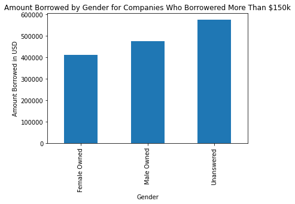

```python
#group by the gender and loan amount of take the mean
plt = df_over.groupby('Gender')['CurrentApprovalAmount'].mean().plot.bar()
plt.set_xlabel("Gender")
plt.set_ylabel("Amount Borrowed in USD")
plt.set_title("Amount Borrowed by Gender for Companies Who Borrowered More Than $150k")
```

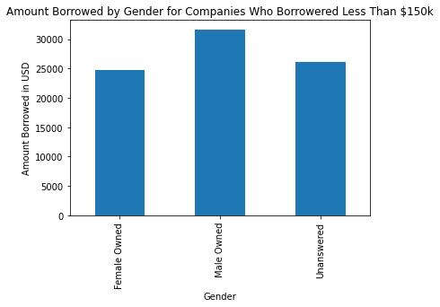

```python
#Repeat same steps for under 150k
plt = df_under.groupby('Gender')['CurrentApprovalAmount'].mean().plot.bar()
plt.set_xlabel("Gender")
plt.set_ylabel("Amount Borrowed in USD")
plt.set_title("Amount Borrowed by Gender for Companies Who Borrowered Less Than $150k")
```

We can see that in both graphs, male owned businsess tended to borrow more on average compared to female owned businesses. It is not immediately obvious as to why this would be the case. It could be that male business owners teneded to be more aggressive in the amount of money that they borrowed. However, it might also be true that the overall lending process was biased towards men, and therefore women recieved a lower average loan amount. This question is difficult to answer, and it would need further analysis.

## Correlation between Loan Amount and Number of Employees Reported

I have another question: *Is the loan amount correlated with the number of reported employees?* I would expect there to be some correlation because the more employees a business has the more expenses they have in the form of wages, and PPP loans were intended to help pay employees. Both the loan amount and the jobs reported are numeric varibles and do not require any pre-processing if we want to see how strongly they correlate with each other. I start checking the correlation between these two columns for both over \$150k and under $150k loan amounts.

```python
#check correlation for over 150k
col_over_1 = df_over['CurrentApprovalAmount']
col_over_2 = df_over['JobsReported']

cor_over = col_over_1.corr(col_over_2)
cor_over
```

```
0.7538269735921438
```

```python
#check correlation for under 150k
col_under_1 = df_under['CurrentApprovalAmount']
col_under_2 = df_under['JobsReported']

cor_under = col_under_1.corr(col_under_2)
cor_under
```

```
0.4556038762493896
```

There is a moderate correlation between the loan amount and the number of employees at the firm when the loan amount is over 150k. This makes sense and follows my prediction. Surprisingly, the correlation between these two variables for the under 150k dataset was weaker. I would like to see both these correlations visually so I can get a better picture.

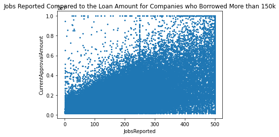

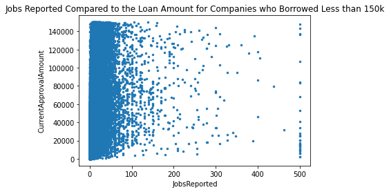

```python
#changed size of dots for readability
plt_over = df_over.plot.scatter(x='JobsReported',y='CurrentApprovalAmount',s=4)
plt_over.set_title("Jobs Reported Compared to the Loan Amount for Companies who Borrowed More than 150k")
plt_under = df_under.plot.scatter(x='JobsReported',y='CurrentApprovalAmount', s=6)
plt_under.set_title("Jobs Reported Compared to the Loan Amount for Companies who Borrowed Less than 150k")
```

The data in the over \$150k dataset behaves as I would expect it to knowing the correlation between the two variables. Likewse, the under \$150k dataset is visibly weakly correlated. However, looking at the under \$150k dataset shows me something interesting: there are many companies with very few employees who applied for loans over \$140k. It could be that these companies had justificaitons for requesting that much money, or it could be indicative that these companies applied for more money than they actually needed. After all, a common issue as discussed by the media with the PPP loans was that the money often seemed to end up being used for the sole benefit of the owner.

# Second Dataset EDA

I will start by importing the poverty data from the USDA.

```python
#Load poverty dataset
%cd /content/drive/MyDrive/Data Science
df_poverty = pd.read_csv("PovertyReportEdited.csv")
df_poverty
```

```
/content/drive/MyDrive/Data Science
```

|  | Name | Unnamed: 1 | Unnamed: 2 | Unnamed: 3 | Percent | Unnamed: 5 | Lower Bound | Upper Bound | Percent.1 | Lower Bound.1 | Upper Bound.1 |
| --- | --- | --- | --- | --- | --- | --- | --- | --- | --- | --- | --- |
| 0 | Alabama | NaN | NaN | NaN | 14.9 | NaN | 14.5 | 15.3 | 20.9 | 20.0 | 21.8 |
| 1 | Alaska | NaN | NaN | NaN | 9.6 | NaN | 9.1 | 10.1 | 12.3 | 11.3 | 13.3 |
| 2 | Arizona | NaN | NaN | NaN | 12.8 | NaN | 12.4 | 13.2 | 17.6 | 16.7 | 18.5 |
| 3 | Arkansas | NaN | NaN | NaN | 15.2 | NaN | 14.7 | 15.7 | 20.8 | 19.8 | 21.8 |
| 4 | California | NaN | NaN | NaN | 11.5 | NaN | 11.3 | 11.7 | 14.6 | 14.2 | 15.0 |
| 5 | Colorado | NaN | NaN | NaN | 9.0 | NaN | 8.7 | 9.3 | 10.6 | 9.9 | 11.3 |
| 6 | Connecticut | NaN | NaN | NaN | 9.7 | NaN | 9.3 | 10.1 | 11.8 | 10.9 | 12.7 |
| 7 | Delaware | NaN | NaN | NaN | 10.9 | NaN | 10.3 | 11.5 | 15.1 | 14.0 | 16.2 |
| 8 | District of Columbia | NaN | NaN | NaN | 15.0 | NaN | 14.0 | 16.0 | 22.3 | 19.4 | 25.2 |
| 9 | Florida | NaN | NaN | NaN | 12.4 | NaN | 12.1 | 12.7 | 17.2 | 16.6 | 17.8 |
| 10 | Georgia | NaN | NaN | NaN | 14.0 | NaN | 13.6 | 14.4 | 19.5 | 18.8 | 20.2 |
| 11 | Hawaii | NaN | NaN | NaN | 8.9 | NaN | 8.4 | 9.4 | 10.4 | 9.4 | 11.4 |
| 12 | Idaho | NaN | NaN | NaN | 10.1 | NaN | 9.6 | 10.6 | 11.6 | 10.7 | 12.5 |
| 13 | Illinois | NaN | NaN | NaN | 11.0 | NaN | 10.8 | 11.2 | 13.9 | 13.4 | 14.4 |
| 14 | Indiana | NaN | NaN | NaN | 11.6 | NaN | 11.3 | 11.9 | 14.9 | 14.2 | 15.6 |
| 15 | Iowa | NaN | NaN | NaN | 10.2 | NaN | 9.8 | 10.6 | 12.0 | 11.2 | 12.8 |
| 16 | Kansas | NaN | NaN | NaN | 10.6 | NaN | 10.2 | 11.0 | 13.0 | 12.1 | 13.9 |
| 17 | Kentucky | NaN | NaN | NaN | 14.9 | NaN | 14.5 | 15.3 | 19.4 | 18.6 | 20.2 |
| 18 | Louisiana | NaN | NaN | NaN | 17.8 | NaN | 17.3 | 18.3 | 24.3 | 23.4 | 25.2 |
| 19 | Maine | NaN | NaN | NaN | 10.6 | NaN | 10.1 | 11.1 | 12.8 | 11.8 | 13.8 |
| 20 | Maryland | NaN | NaN | NaN | 9.0 | NaN | 8.7 | 9.3 | 11.2 | 10.4 | 12.0 |
| 21 | Massachusetts | NaN | NaN | NaN | 9.4 | NaN | 9.1 | 9.7 | 10.9 | 10.2 | 11.6 |
| 22 | Michigan | NaN | NaN | NaN | 12.6 | NaN | 12.3 | 12.9 | 16.8 | 16.2 | 17.4 |
| 23 | Minnesota | NaN | NaN | NaN | 8.3 | NaN | 8.0 | 8.6 | 9.5 | 8.8 | 10.2 |
| 24 | Mississippi | NaN | NaN | NaN | 18.7 | NaN | 18.2 | 19.2 | 26.0 | 24.9 | 27.1 |
| 25 | Missouri | NaN | NaN | NaN | 12.1 | NaN | 11.8 | 12.4 | 15.5 | 14.8 | 16.2 |
| 26 | Montana | NaN | NaN | NaN | 12.4 | NaN | 11.9 | 12.9 | 14.6 | 13.6 | 15.6 |
| 27 | National | NaN | NaN | NaN | 11.9 | NaN | 11.9 | 11.9 | 15.7 | 15.7 | 15.7 |
| 28 | Nebraska | NaN | NaN | NaN | 9.2 | NaN | 8.8 | 9.6 | 10.1 | 9.3 | 10.9 |
| 29 | Nevada | NaN | NaN | NaN | 12.5 | NaN | 12.0 | 13.0 | 16.7 | 15.8 | 17.6 |
| 30 | New Hampshire | NaN | NaN | NaN | 7.0 | NaN | 6.5 | 7.5 | 8.4 | 7.4 | 9.4 |
| 31 | New Jersey | NaN | NaN | NaN | 9.4 | NaN | 9.1 | 9.7 | 12.6 | 11.9 | 13.3 |
| 32 | New Mexico | NaN | NaN | NaN | 16.8 | NaN | 16.2 | 17.4 | 21.6 | 20.4 | 22.8 |
| 33 | New York | NaN | NaN | NaN | 12.7 | NaN | 12.5 | 12.9 | 16.7 | 16.1 | 17.3 |
| 34 | North Carolina | NaN | NaN | NaN | 12.9 | NaN | 12.6 | 13.2 | 17.9 | 17.1 | 18.7 |
| 35 | North Dakota | NaN | NaN | NaN | 10.2 | NaN | 9.5 | 10.9 | 10.9 | 9.9 | 11.9 |
| 36 | Ohio | NaN | NaN | NaN | 12.6 | NaN | 12.3 | 12.9 | 16.6 | 15.9 | 17.3 |
| 37 | Oklahoma | NaN | NaN | NaN | 14.3 | NaN | 13.9 | 14.7 | 18.6 | 17.8 | 19.4 |
| 38 | Oregon | NaN | NaN | NaN | 11.0 | NaN | 10.6 | 11.4 | 12.2 | 11.4 | 13.0 |
| 39 | Pennsylvania | NaN | NaN | NaN | 10.9 | NaN | 10.7 | 11.1 | 14.3 | 13.7 | 14.9 |
| 40 | Rhode Island | NaN | NaN | NaN | 10.6 | NaN | 10.0 | 11.2 | 14.5 | 13.4 | 15.6 |
| 41 | South Carolina | NaN | NaN | NaN | 13.8 | NaN | 13.4 | 14.2 | 18.7 | 17.9 | 19.5 |
| 42 | South Dakota | NaN | NaN | NaN | 11.6 | NaN | 11.1 | 12.1 | 13.9 | 13.0 | 14.8 |
| 43 | Tennessee | NaN | NaN | NaN | 13.6 | NaN | 13.2 | 14.0 | 18.4 | 17.6 | 19.2 |
| 44 | Texas | NaN | NaN | NaN | 13.4 | NaN | 13.2 | 13.6 | 18.8 | 18.2 | 19.4 |
| 45 | Utah | NaN | NaN | NaN | 7.3 | NaN | 6.9 | 7.7 | 7.5 | 6.8 | 8.2 |
| 46 | Vermont | NaN | NaN | NaN | 9.4 | NaN | 8.8 | 10.0 | 10.0 | 9.0 | 11.0 |
| 47 | Virginia | NaN | NaN | NaN | 9.2 | NaN | 8.9 | 9.5 | 12.2 | 11.6 | 12.8 |
| 48 | Washington | NaN | NaN | NaN | 9.5 | NaN | 9.2 | 9.8 | 11.0 | 10.3 | 11.7 |
| 49 | West Virginia | NaN | NaN | NaN | 15.8 | NaN | 15.3 | 16.3 | 20.3 | 19.2 | 21.4 |
| 50 | Wisconsin | NaN | NaN | NaN | 10.0 | NaN | 9.7 | 10.3 | 12.4 | 11.7 | 13.1 |
| 51 | Wyoming | NaN | NaN | NaN | 9.2 | NaN | 8.6 | 9.8 | 10.3 | 9.2 | 11.4 |

As we can see, the columns are pretty messy, and the variable names which separate the poverty percent per state and for children are unclear. I am going to have to do some cleaning up in order to make this dataset follow the principles of tidy data. Since I am planning on merging this dataset with the PPP loan dataframe, I am going to need a primary key to merge on—which in this case would be the state.

## Mapping the States to 2 letter codes

The state in this dataset is currently the whole name. I need to get the two letter abbreviation in order to merge it, so I decided to rename all of the states using a map function. I figured this was an issue that had been been dealt with before. Thankfully, I was able to look up a map list on Roger Allen's Github.

```python
df_poverty['state'] = df_poverty['Name'].map({"Alabama": "AL",
    "Alaska": "AK", #https://gist.github.com/rogerallen/1583593
    "Arizona": "AZ",
    "Arkansas": "AR",
    "California": "CA",
    "Colorado": "CO",
    "Connecticut": "CT",
    "Delaware": "DE",
    "Florida": "FL",
    "Georgia": "GA",
    "Hawaii": "HI",
    "Idaho": "ID",
    "Illinois": "IL",
    "Indiana": "IN",
    "Iowa": "IA",
    "Kansas": "KS",
    "Kentucky": "KY",
    "Louisiana": "LA",
    "Maine": "ME",
    "Maryland": "MD",
    "Massachusetts": "MA",
    "Michigan": "MI",
    "Minnesota": "MN",
    "Mississippi": "MS",
    "Missouri": "MO",
    "Montana": "MT",
    "Nebraska": "NE",
    "Nevada": "NV",
    "New Hampshire": "NH",
    "New Jersey": "NJ",
    "New Mexico": "NM",
    "New York": "NY",
    "North Carolina": "NC",
    "North Dakota": "ND",
    "Ohio": "OH",
    "Oklahoma": "OK",
    "Oregon": "OR",
    "Pennsylvania": "PA",
    "Rhode Island": "RI",
    "South Carolina": "SC",
    "South Dakota": "SD",
    "Tennessee": "TN",
    "Texas": "TX",
    "Utah": "UT",
    "Vermont": "VT",
    "Virginia": "VA",
    "Washington": "WA",
    "West Virginia": "WV",
    "Wisconsin": "WI",
    "Wyoming": "WY",
    "District of Columbia": "DC",
    "American Samoa": "AS",
    "Guam": "GU",
    "Northern Mariana Islands": "MP",
    "Puerto Rico": "PR",
    "United States Minor Outlying Islands": "UM",
    "U.S. Virgin Islands": "VI",
})
df_poverty.drop(columns=["Name","Unnamed: 1","Unnamed: 2","Unnamed: 3","Unnamed: 5"], inplace=True)
df_poverty.rename(columns={"Percent":"Percent_All",
                           "Lower Bound":"Lower_Bound_All",
                           "Upper Bound":"Upper_Bound_All",
                           "Percent.1":"Percent_Child",
                           "Lower Bound.1":"Lower_Bound_Child",
                           "Upper Bound.1":"Upper_Bound_Child",}, inplace=True)
df_poverty
```

|  | Percent_All | Lower_Bound_All | Upper_Bound_All | Percent_Child | Lower_Bound_Child | Upper_Bound_Child | state |
| --- | --- | --- | --- | --- | --- | --- | --- |
| 0 | 14.9 | 14.5 | 15.3 | 20.9 | 20.0 | 21.8 | AL |
| 1 | 9.6 | 9.1 | 10.1 | 12.3 | 11.3 | 13.3 | AK |
| 2 | 12.8 | 12.4 | 13.2 | 17.6 | 16.7 | 18.5 | AZ |
| 3 | 15.2 | 14.7 | 15.7 | 20.8 | 19.8 | 21.8 | AR |
| 4 | 11.5 | 11.3 | 11.7 | 14.6 | 14.2 | 15.0 | CA |
| 5 | 9.0 | 8.7 | 9.3 | 10.6 | 9.9 | 11.3 | CO |
| 6 | 9.7 | 9.3 | 10.1 | 11.8 | 10.9 | 12.7 | CT |
| 7 | 10.9 | 10.3 | 11.5 | 15.1 | 14.0 | 16.2 | DE |
| 8 | 15.0 | 14.0 | 16.0 | 22.3 | 19.4 | 25.2 | DC |
| 9 | 12.4 | 12.1 | 12.7 | 17.2 | 16.6 | 17.8 | FL |
| 10 | 14.0 | 13.6 | 14.4 | 19.5 | 18.8 | 20.2 | GA |
| 11 | 8.9 | 8.4 | 9.4 | 10.4 | 9.4 | 11.4 | HI |
| 12 | 10.1 | 9.6 | 10.6 | 11.6 | 10.7 | 12.5 | ID |
| 13 | 11.0 | 10.8 | 11.2 | 13.9 | 13.4 | 14.4 | IL |
| 14 | 11.6 | 11.3 | 11.9 | 14.9 | 14.2 | 15.6 | IN |
| 15 | 10.2 | 9.8 | 10.6 | 12.0 | 11.2 | 12.8 | IA |
| 16 | 10.6 | 10.2 | 11.0 | 13.0 | 12.1 | 13.9 | KS |
| 17 | 14.9 | 14.5 | 15.3 | 19.4 | 18.6 | 20.2 | KY |
| 18 | 17.8 | 17.3 | 18.3 | 24.3 | 23.4 | 25.2 | LA |
| 19 | 10.6 | 10.1 | 11.1 | 12.8 | 11.8 | 13.8 | ME |
| 20 | 9.0 | 8.7 | 9.3 | 11.2 | 10.4 | 12.0 | MD |
| 21 | 9.4 | 9.1 | 9.7 | 10.9 | 10.2 | 11.6 | MA |
| 22 | 12.6 | 12.3 | 12.9 | 16.8 | 16.2 | 17.4 | MI |
| 23 | 8.3 | 8.0 | 8.6 | 9.5 | 8.8 | 10.2 | MN |
| 24 | 18.7 | 18.2 | 19.2 | 26.0 | 24.9 | 27.1 | MS |
| 25 | 12.1 | 11.8 | 12.4 | 15.5 | 14.8 | 16.2 | MO |
| 26 | 12.4 | 11.9 | 12.9 | 14.6 | 13.6 | 15.6 | MT |
| 27 | 11.9 | 11.9 | 11.9 | 15.7 | 15.7 | 15.7 | NaN |
| 28 | 9.2 | 8.8 | 9.6 | 10.1 | 9.3 | 10.9 | NE |
| 29 | 12.5 | 12.0 | 13.0 | 16.7 | 15.8 | 17.6 | NV |
| 30 | 7.0 | 6.5 | 7.5 | 8.4 | 7.4 | 9.4 | NH |
| 31 | 9.4 | 9.1 | 9.7 | 12.6 | 11.9 | 13.3 | NJ |
| 32 | 16.8 | 16.2 | 17.4 | 21.6 | 20.4 | 22.8 | NM |
| 33 | 12.7 | 12.5 | 12.9 | 16.7 | 16.1 | 17.3 | NY |
| 34 | 12.9 | 12.6 | 13.2 | 17.9 | 17.1 | 18.7 | NC |
| 35 | 10.2 | 9.5 | 10.9 | 10.9 | 9.9 | 11.9 | ND |
| 36 | 12.6 | 12.3 | 12.9 | 16.6 | 15.9 | 17.3 | OH |
| 37 | 14.3 | 13.9 | 14.7 | 18.6 | 17.8 | 19.4 | OK |
| 38 | 11.0 | 10.6 | 11.4 | 12.2 | 11.4 | 13.0 | OR |
| 39 | 10.9 | 10.7 | 11.1 | 14.3 | 13.7 | 14.9 | PA |
| 40 | 10.6 | 10.0 | 11.2 | 14.5 | 13.4 | 15.6 | RI |
| 41 | 13.8 | 13.4 | 14.2 | 18.7 | 17.9 | 19.5 | SC |
| 42 | 11.6 | 11.1 | 12.1 | 13.9 | 13.0 | 14.8 | SD |
| 43 | 13.6 | 13.2 | 14.0 | 18.4 | 17.6 | 19.2 | TN |
| 44 | 13.4 | 13.2 | 13.6 | 18.8 | 18.2 | 19.4 | TX |
| 45 | 7.3 | 6.9 | 7.7 | 7.5 | 6.8 | 8.2 | UT |
| 46 | 9.4 | 8.8 | 10.0 | 10.0 | 9.0 | 11.0 | VT |
| 47 | 9.2 | 8.9 | 9.5 | 12.2 | 11.6 | 12.8 | VA |
| 48 | 9.5 | 9.2 | 9.8 | 11.0 | 10.3 | 11.7 | WA |
| 49 | 15.8 | 15.3 | 16.3 | 20.3 | 19.2 | 21.4 | WV |
| 50 | 10.0 | 9.7 | 10.3 | 12.4 | 11.7 | 13.1 | WI |
| 51 | 9.2 | 8.6 | 9.8 | 10.3 | 9.2 | 11.4 | WY |

That solves the problem of the state names. However, there are some columns with nothing in them that appeared to be created when I first read in the dataset. I dropped those columns. I also renamed the other variable names so the are easier to differntiate. I am going to end the variable names with _All when they encompass all demographics and _Child when the variable refers to children aged 0-17. I will also check the dtypes just to be sure that everything is loaded properly.

```python
df_poverty.dtypes
```

```
Percent_All          float64
Lower_Bound_All      float64
Upper_Bound_All      float64
Percent_Child        float64
Lower_Bound_Child    float64
Upper_Bound_Child    float64
state                 object
dtype: object
```

### Some measures of spread

```python
df_poverty['Percent_All'].mean()
```

```
11.692307692307692
```

```python
df_poverty['Percent_All'].median()
```

```
11.25
```

The median and the mean are fairly close to each other, which means that the data isn't very skewed one way or the other. To get a better idea about the spread, I want to calculate the Interquartile Range (IQR).

```python
q3, q1 = np.percentile(df_poverty['Percent_All'], [75 ,25])
iqr = q3 - q1
iqr
```

```
3.450000000000001
```

From this value, we can see that the middle 50% of poverty rates in the United States has a spread of 3.45%.

## Merging with the PPP Dataframe

Now that I have a better understanding of the data, I'm ready to merge it with the PPP data subsample that I am using.

```python
%cd /content/drive/MyDrive/Capstone_CMPS/PPP_Data
import glob
fileNames = glob.glob('*.csv')
df_list = [pd.read_csv(dataset, sep=",").sample(80000, random_state = 39) for dataset in fileNames[1:]] #Grab a random sample of 80000 observations for each dataset ignoring the dataframe over 150k
ppp_df = pd.concat(df_list, ignore_index=True) #concat all those dataframes together
ppp_df.head()
```

```
/content/drive/My Drive/Capstone_CMPS/PPP_Data
```

|  | LoanNumber | DateApproved | SBAOfficeCode | ProcessingMethod | BorrowerName | BorrowerAddress | BorrowerCity | BorrowerState | BorrowerZip | LoanStatusDate | LoanStatus | Term | SBAGuarantyPercentage | InitialApprovalAmount | CurrentApprovalAmount | UndisbursedAmount | FranchiseName | ServicingLenderLocationID | ServicingLenderName | ServicingLenderAddress | ServicingLenderCity | ServicingLenderState | ServicingLenderZip | RuralUrbanIndicator | HubzoneIndicator | LMIIndicator | BusinessAgeDescription | ProjectCity | ProjectCountyName | … |
| --- | --- | --- | --- | --- | --- | --- | --- | --- | --- | --- | --- | --- | --- | --- | --- | --- | --- | --- | --- | --- | --- | --- | --- | --- | --- | --- | --- | --- | --- | --- |
| 0 | 7282478404 | 02/11/2021 | 988.0 | PPP | EDWARD FRENETTE | 4904 E Trails End Dr | Flagstaff | AZ | 86004-2756 | 08/13/2021 | Paid in Full | 60 | 100 | 6250.0 | 6250.0 | 0.0 | NaN | 529471.0 | Itria Ventures LLC | One Penn Plaza, Suite 4530 | New York | NY | 10119 | R | N | N | Existing or more than 2 years old | Flagstaff | COCONINO | … |
| 1 | 1111538309 | 01/16/2021 | 459.0 | PPS | VERVE REAL ESTATE LLC | 7092 Fain Park Dr | Montgomery | AL | 36117-7812 | 07/13/2021 | Paid in Full | 60 | 100 | 6700.0 | 6700.0 | 0.0 | NaN | 398147.0 | American Commerce Bank, National Association | 400 US Hwy 27 By-Pass | BREMEN | GA | 30110-1973 | U | N | N | Existing or more than 2 years old | Montgomery | MONTGOMERY | … |
| 2 | 8257678909 | 05/11/2021 | 988.0 | PPP | ERINN GILLIS | 9920 W Camelback Rd | Phoenix | AZ | 85037-5060 | 08/09/2022 | Paid in Full | 60 | 100 | 16665.0 | 16665.0 | 0.0 | NaN | 188361.0 | Prestamos CDFI, LLC | 1024 East Buckeye Road Suite 270 | Phoenix | AZ | 85034 | U | N | N | Existing or more than 2 years old | Phoenix | MARICOPA | … |
| 3 | 2262338408 | 02/03/2021 | 459.0 | PPS | JOSHUA PATRICK | 13001 Chimney Springs Cir SE | Huntsville | AL | 35803-2441 | 11/20/2021 | Paid in Full | 60 | 100 | 13332.5 | 13332.5 | 0.0 | NaN | 19248.0 | Synovus Bank | 1148 Broadway | COLUMBUS | GA | 31901-2429 | U | N | N | Existing or more than 2 years old | Huntsville | MADISON | … |
| 4 | 8701808407 | 02/13/2021 | 931.0 | PPS | PRIME SOLAR SOLUTIONS LLC | 8084 Old Auburn Rd Ste C | Citrus Heights | CA | 95610-2559 | 01/21/2022 | Paid in Full | 60 | 100 | 134787.0 | 134787.0 | 0.0 | NaN | 48270.0 | JPMorgan Chase Bank, National Association | 1111 Polaris Pkwy | COLUMBUS | OH | 43240-2031 | U | N | N | Existing or more than 2 years old | Citrus Heights | SACRAMENTO | … |

```python
#Merge two datasets together
merged_df = ppp_df.merge(df_poverty, how="left", left_on = ['BorrowerState'], right_on=['state'])
merged_df.head()
```

|  | LoanNumber | DateApproved | SBAOfficeCode | ProcessingMethod | BorrowerName | BorrowerAddress | BorrowerCity | BorrowerState | BorrowerZip | LoanStatusDate | LoanStatus | Term | SBAGuarantyPercentage | InitialApprovalAmount | CurrentApprovalAmount | UndisbursedAmount | FranchiseName | ServicingLenderLocationID | ServicingLenderName | ServicingLenderAddress | ServicingLenderCity | ServicingLenderState | ServicingLenderZip | RuralUrbanIndicator | HubzoneIndicator | LMIIndicator | BusinessAgeDescription | ProjectCity | ProjectCountyName | … |
| --- | --- | --- | --- | --- | --- | --- | --- | --- | --- | --- | --- | --- | --- | --- | --- | --- | --- | --- | --- | --- | --- | --- | --- | --- | --- | --- | --- | --- | --- | --- |
| 0 | 7282478404 | 02/11/2021 | 988.0 | PPP | EDWARD FRENETTE | 4904 E Trails End Dr | Flagstaff | AZ | 86004-2756 | 08/13/2021 | Paid in Full | 60 | 100 | 6250.0 | 6250.0 | 0.0 | NaN | 529471.0 | Itria Ventures LLC | One Penn Plaza, Suite 4530 | New York | NY | 10119 | R | N | N | Existing or more than 2 years old | Flagstaff | COCONINO | … |
| 1 | 1111538309 | 01/16/2021 | 459.0 | PPS | VERVE REAL ESTATE LLC | 7092 Fain Park Dr | Montgomery | AL | 36117-7812 | 07/13/2021 | Paid in Full | 60 | 100 | 6700.0 | 6700.0 | 0.0 | NaN | 398147.0 | American Commerce Bank, National Association | 400 US Hwy 27 By-Pass | BREMEN | GA | 30110-1973 | U | N | N | Existing or more than 2 years old | Montgomery | MONTGOMERY | … |
| 2 | 8257678909 | 05/11/2021 | 988.0 | PPP | ERINN GILLIS | 9920 W Camelback Rd | Phoenix | AZ | 85037-5060 | 08/09/2022 | Paid in Full | 60 | 100 | 16665.0 | 16665.0 | 0.0 | NaN | 188361.0 | Prestamos CDFI, LLC | 1024 East Buckeye Road Suite 270 | Phoenix | AZ | 85034 | U | N | N | Existing or more than 2 years old | Phoenix | MARICOPA | … |
| 3 | 2262338408 | 02/03/2021 | 459.0 | PPS | JOSHUA PATRICK | 13001 Chimney Springs Cir SE | Huntsville | AL | 35803-2441 | 11/20/2021 | Paid in Full | 60 | 100 | 13332.5 | 13332.5 | 0.0 | NaN | 19248.0 | Synovus Bank | 1148 Broadway | COLUMBUS | GA | 31901-2429 | U | N | N | Existing or more than 2 years old | Huntsville | MADISON | … |
| 4 | 8701808407 | 02/13/2021 | 931.0 | PPS | PRIME SOLAR SOLUTIONS LLC | 8084 Old Auburn Rd Ste C | Citrus Heights | CA | 95610-2559 | 01/21/2022 | Paid in Full | 60 | 100 | 134787.0 | 134787.0 | 0.0 | NaN | 48270.0 | JPMorgan Chase Bank, National Association | 1111 Polaris Pkwy | COLUMBUS | OH | 43240-2031 | U | N | N | Existing or more than 2 years old | Citrus Heights | SACRAMENTO | … |

We can see that the PPP data merged successfully with the poverty data and it is tagged on to the end of our new dataset. Now that the two datasets are merged together, we can see how many PPP loans were taken out in each state compared to the poverty rate.

```python
merged_df.groupby('state')['Percent_All'].value_counts()
```

```
state  Percent_All
AK     9.6              1880
AL     14.9            13933
AR     15.2             8537
AZ     12.8            13628
CA     11.5           101472
CO     9.0             15457
CT     9.7              9323
DC     15.0             2214
DE     10.9             2190
FL     12.4            82021
GA     14.0            46793
HI     8.9              3574
IA     10.2            14567
ID     10.1             4243
IL     11.0            51390
IN     11.6            15139
KS     10.6            10566
KY     14.9            10615
LA     17.8            17910
MA     9.4             16852
MD     9.0             15351
ME     10.6             3934
MI     12.6            23299
MN     8.3             18089
MO     12.1            19240
MS     18.7            11844
MT     12.4             3955
NC     12.9            21113
ND     10.2             4345
NE     9.2              9482
NH     7.0              3119
NJ     9.4             23945
NM     16.8             3248
NV     12.5             9843
NY     12.7            58716
OH     12.6            28510
OK     14.3            12939
OR     11.0             9115
PA     10.9            26860
RI     10.6             2687
SC     13.8            12486
SD     11.6             5396
TN     13.6            19202
TX     13.4            76584
UT     7.3              6704
VA     9.2             25844
VT     9.4              2541
WA     9.5             22526
WI     10.0            22765
WV     15.8             4071
WY     9.2              3188
Name: Percent_All, dtype: int64
```

# Mapping States into regions

I am going to start building my model along with any nescessary pre-processing. In the PPP Dataset, which state the loan borrower is from is a feature that I would like to include in my model. However, having dummy variables for all the states would be overkill. Instead, I would like to put each state into the U.S. region it belongs in. There will be four regions:

1. West
2. South
3. Northeast
4. Midwest

I will start by adding another dataset provided by [Chris Halpert](https://github.com/cphalpert/census-regions/blob/master/us%20census%20bureau%20regions%20and%20divisions.csv) that has the State and region for each state. This will allow me to do a simple merge to have the Region mapped to the proper state.

```python
%cd /content/drive/MyDrive/Capstone_CMPS
regionData = pd.read_excel("regionData.xlsx")
regionData.drop(columns=['Unnamed: 0'], axis = 1, inplace=True)
regionData['State_Code'] = regionData['State Code']
regionData.drop(columns=['State Code'], axis = 1, inplace=True)
regionData
```

```
/content/drive/MyDrive/Capstone_CMPS
```

|  | State | Region | Division | State_Code |
| --- | --- | --- | --- | --- |
| 0 | Alaska | West | Pacific | AK |
| 1 | Alabama | South | East South Central | AL |
| 2 | Arkansas | South | West South Central | AR |
| 3 | Arizona | West | Mountain | AZ |
| 4 | California | West | Pacific | CA |
| 5 | Colorado | West | Mountain | CO |
| 6 | Connecticut | Northeast | New England | CT |
| 7 | District of Columbia | South | South Atlantic | DC |
| 8 | Delaware | South | South Atlantic | DE |
| 9 | Florida | South | South Atlantic | FL |
| 10 | Georgia | South | South Atlantic | GA |
| 11 | Hawaii | West | Pacific | HI |
| 12 | Iowa | Midwest | West North Central | IA |
| 13 | Idaho | West | Mountain | ID |
| 14 | Illinois | Midwest | East North Central | IL |
| 15 | Indiana | Midwest | East North Central | IN |
| 16 | Kansas | Midwest | West North Central | KS |
| 17 | Kentucky | South | East South Central | KY |
| 18 | Louisiana | South | West South Central | LA |
| 19 | Massachusetts | Northeast | New England | MA |
| 20 | Maryland | South | South Atlantic | MD |
| 21 | Maine | Northeast | New England | ME |
| 22 | Michigan | Midwest | East North Central | MI |
| 23 | Minnesota | Midwest | West North Central | MN |
| 24 | Missouri | Midwest | West North Central | MO |
| 25 | Mississippi | South | East South Central | MS |
| 26 | Montana | West | Mountain | MT |
| 27 | North Carolina | South | South Atlantic | NC |
| 28 | North Dakota | Midwest | West North Central | ND |
| 29 | Nebraska | Midwest | West North Central | NE |
| 30 | New Hampshire | Northeast | New England | NH |
| 31 | New Jersey | Northeast | Middle Atlantic | NJ |
| 32 | New Mexico | West | Mountain | NM |
| 33 | Nevada | West | Mountain | NV |
| 34 | New York | Northeast | Middle Atlantic | NY |
| 35 | Ohio | Midwest | East North Central | OH |
| 36 | Oklahoma | South | West South Central | OK |
| 37 | Oregon | West | Pacific | OR |
| 38 | Pennsylvania | Northeast | Middle Atlantic | PA |
| 39 | Rhode Island | Northeast | New England | RI |
| 40 | South Carolina | South | South Atlantic | SC |
| 41 | South Dakota | Midwest | West North Central | SD |
| 42 | Tennessee | South | East South Central | TN |
| 43 | Texas | South | West South Central | TX |
| 44 | Utah | West | Mountain | UT |
| 45 | Virginia | South | South Atlantic | VA |
| 46 | Vermont | Northeast | New England | VT |
| 47 | Washington | West | Pacific | WA |
| 48 | Wisconsin | Midwest | East North Central | WI |
| 49 | West Virginia | South | South Atlantic | WV |
| 50 | Wyoming | West | Mountain | WY |

I also did a little bit of minor data cleaning. One of the columns was incorrectly imported as *Unnamed: 0* so I dropped it from the Dataframe. I also renamed the State Code column to State_Code to better fit the rest of the features I am going to use.

I am now going to begin preprocessing the data in preparation for the Machine Learning model that I will be constructing. In order to do this, I am going to perform some feature manipulation on the PPP dataset. I will start off by creating binary variables for Gender where 1 represents the borrower is female a 0 represents male.

After creating these dummy variables, I will merge the PPP dataframe with the region data in order to correctly map each state to the region it should be in.

```python
merged_df['Gender_Binary'] = np.where(merged_df['Gender'] == 'Female Owned',1,0) #1 represents female
merged_df['Gender_Answer'] = np.where(merged_df['Gender'] == 'Female Owned',1,0)
merged_df['Gender_Answer'] = np.where(merged_df['Gender'] == 'Male Owned',1,0) #1 means that the borrower answered the question
merged_df['Veteran_Binary'] = np.where(merged_df['Veteran'] == 'Veteran',1,0)
ppp_df_merged = merged_df.merge(regionData, how = 'left', left_on = ['BorrowerState'], right_on = ['State_Code'])
ppp_df_merged.sample(5) #random subsample
```

|  | LoanNumber | DateApproved | SBAOfficeCode | ProcessingMethod | BorrowerName | BorrowerAddress | BorrowerCity | BorrowerState | BorrowerZip | LoanStatusDate | LoanStatus | Term | SBAGuarantyPercentage | InitialApprovalAmount | CurrentApprovalAmount | UndisbursedAmount | FranchiseName | ServicingLenderLocationID | ServicingLenderName | ServicingLenderAddress | ServicingLenderCity | ServicingLenderState | ServicingLenderZip | RuralUrbanIndicator | HubzoneIndicator | LMIIndicator | BusinessAgeDescription | ProjectCity | ProjectCountyName | … |
| --- | --- | --- | --- | --- | --- | --- | --- | --- | --- | --- | --- | --- | --- | --- | --- | --- | --- | --- | --- | --- | --- | --- | --- | --- | --- | --- | --- | --- | --- | --- |
| 771771 | 1308957706 | 05/01/2020 | 610.0 | PPP | ALBERTO AMBRIZ DDS, P.C. | 9400 N CENTRAL EXPY STE 220 | DALLAS | TX | 75231 | 05/21/2021 | Paid in Full | 24 | 100 | 27902.0 | 27902.0 | 0.0 | NaN | 48270.0 | JPMorgan Chase Bank, National Association | 1111 Polaris Pkwy | COLUMBUS | OH | 43240-2031 | U | N | Y | Existing or more than 2 years old | DALLAS | DALLAS | … |
| 249595 | 1356787207 | 04/15/2020 | 507.0 | PPP | PROGRESSIVE MANAGEMENT SERIVCES LLC | 401 W HALF DAY ROAD | BUFFALO GROVE | IL | 60089-6548 | 03/05/2021 | Paid in Full | 24 | 100 | 104500.0 | 104500.0 | 0.0 | NaN | 124396.0 | American Community Bank & Trust | 1290 Lake Ave | WOODSTOCK | IL | 60098-7415 | U | N | N | Existing or more than 2 years old | BUFFALO GROVE | LAKE | … |
| 345934 | 6497229006 | 05/22/2021 | 679.0 | PPP | DK&A CONSULTANT LLC | 6335 Cyrus Ave | Baton Rouge | LA | 70805-4641 | NaN | Exemption 4 | 60 | 100 | 19687.0 | 19687.0 | 0.0 | NaN | 529472.0 | Capital Plus Financial, LLC | 2247 Central Drive | Bedford | TX | 76021 | U | Y | Y | Existing or more than 2 years old | Baton Rouge | EAST BATON ROUGE | … |
| 911661 | 3565548403 | 02/05/2021 | 912.0 | PPS | KEVIN CHIN | 1674 Post St Ste 1 | San Francisco | CA | 94115-3682 | 03/15/2022 | Paid in Full | 60 | 100 | 20832.0 | 20832.0 | 0.0 | SVN | 72601.0 | Zions Bank, A Division of | 1 S Main St | SALT LAKE CITY | UT | 84133-1109 | U | Y | Y | Existing or more than 2 years old | San Francisco | SAN FRANCISCO | … |
| 675326 | 3499238503 | 02/24/2021 | 358.0 | PPP | MICHAEL MARTIN | 1368 Tennessee Ave | Pittsburgh | PA | 15216-2514 | 08/13/2021 | Paid in Full | 60 | 100 | 10000.0 | 10000.0 | 0.0 | NaN | 529471.0 | Itria Ventures LLC | One Penn Plaza, Suite 4530 | New York | NY | 10119 | U | N | N | Existing or more than 2 years old | Pittsburgh | ALLEGHENY | … |

### Get_Dummies issue

I was having issues with the built in Pandas get_dummies function. It did not run in any reasonable amount of tieme, so I decided to do my own version of dummy encoding for the regions. This is what my code does when run:

1. Create a list of each state in each region.
2. Add states to the correct region list.
3. Create four columns (or bins) each named one of the regions in the PPP Dataframe.
4. Add a 1 to the column if the borrower's state is in the correct bin and 0 for the rest.

This solved my issue with the get_dummies function, and allows me to incorporate the regions into my model.

```python
south_list, west_list, northeast_list, midwest_list = [],[],[],[] #create emtpy lists for the states
for index, row in regionData.iterrows(): #Add states to the correct list depending on the region
  if row.Region == 'South':
    south_list.append(row.State_Code)
  if row.Region == 'West':
    west_list.append(row.State_Code)
  if row.Region == 'Northeast':
    northeast_list.append(row.State_Code)
  if row.Region == 'Midwest':
    midwest_list.append(row.State_Code)

#Basically add a 1 if it is in that region, otherwise add a 0
ppp_df_merged['South'] = np.where(ppp_df_merged['BorrowerState'].isin(south_list),1,0)
ppp_df_merged['West'] = np.where(ppp_df_merged['BorrowerState'].isin(west_list),1,0)
ppp_df_merged['Northeast'] = np.where(ppp_df_merged['BorrowerState'].isin(northeast_list),1,0)
ppp_df_merged['Midwest'] = np.where(ppp_df_merged['BorrowerState'].isin(midwest_list),1,0)

ppp_df_merged.sample(5)
```

|  | LoanNumber | DateApproved | SBAOfficeCode | ProcessingMethod | BorrowerName | BorrowerAddress | BorrowerCity | BorrowerState | BorrowerZip | LoanStatusDate | LoanStatus | Term | SBAGuarantyPercentage | InitialApprovalAmount | CurrentApprovalAmount | UndisbursedAmount | FranchiseName | ServicingLenderLocationID | ServicingLenderName | ServicingLenderAddress | ServicingLenderCity | ServicingLenderState | ServicingLenderZip | RuralUrbanIndicator | HubzoneIndicator | LMIIndicator | BusinessAgeDescription | ProjectCity | ProjectCountyName | … |
| --- | --- | --- | --- | --- | --- | --- | --- | --- | --- | --- | --- | --- | --- | --- | --- | --- | --- | --- | --- | --- | --- | --- | --- | --- | --- | --- | --- | --- | --- | --- |
| 432777 | 6894358508 | 03/04/2021 | 508.0 | PPS | REESE BROTHERS REPAIR LLC | 102 S. CENTRAL AVENUE | GENEVA | MN | 56035 | NaN | Exemption 4 | 60 | 100 | 17879.00 | 17879.00 | 0.0 | NaN | 21023.0 | Byline Bank | 180 N LaSalle St, Ste 300 | CHICAGO | IL | 60601-3110 | R | N | N | Existing or more than 2 years old | GENEVA | FREEBORN | … |
| 162406 | 8842328801 | 04/22/2021 | 405.0 | PPS | TAMIKA WALLER | 115 Pine Cone Rd NW | Milledgeville | GA | 31061-7902 | 01/06/2022 | Paid in Full | 60 | 100 | 2898.55 | 2898.55 | 0.0 | NaN | 529050.0 | Square Capital, LLC | 1455 Market Street, Suite 600 | San Francisco | CA | 94103 | R | Y | N | Existing or more than 2 years old | Milledgeville | BALDWIN | … |
| 836684 | 1271248500 | 02/18/2021 | 1013.0 | PPS | PACIFIC WINDOW COVERINGS | 12656 100th Ave NE | Kirkland | WA | 98034-2727 | 12/08/2021 | Paid in Full | 60 | 100 | 7465.29 | 7465.29 | 0.0 | NaN | 529050.0 | Square Capital, LLC | 1455 Market Street, Suite 600 | San Francisco | CA | 94103 | U | N | N | Existing or more than 2 years old | Kirkland | KING | … |
| 699728 | 2078627405 | 05/05/2020 | 474.0 | PPP | LAVA NAILS AND SPA LLC | 2025 Congress Parkway 25 CROSS CREEK DRIVE | Athens | TN | 37303 | 12/01/2021 | Paid in Full | 24 | 100 | 6250.00 | 6250.00 | 0.0 | NaN | 122043.0 | WebBank | 215 S State St, Ste 1000 | SALT LAKE CITY | UT | 84111-2336 | R | N | Y | Existing or more than 2 years old | Athens | MCMINN | … |
| 309650 | 6176128809 | 04/19/2021 | 507.0 | PPP | IDA JONES | 4921 190th St | Country Club Hills | IL | 60478-5910 | 11/19/2021 | Paid in Full | 60 | 100 | 20833.00 | 20833.00 | 0.0 | NaN | 509316.0 | Harvest Small Business Finance, LLC | 24422 Avenida de la Carlota Suite 232 | Laguna Hills | CA | 92653 | U | N | Y | Existing or more than 2 years old | Country Club Hills | COOK | … |

By taking a random subsample we can see that everything was correctly dummified into the appropriate region.

# Creating the Model

## Getting rid of NaNs

Now that all the data pre-processing is done, we can begin to work on our model. I want this model to address questions 3 and 4 from my project goals section:

- Could I identify other relevant features that might explain a difference in loan amounts with men compared to women?
- Were the loan amounts equitable?

I will be using SciKit Learn to make my machine learning model. The first thing I need to do is import some features from the sklearn library.

The first thing I will do is remove any observations where the gender of the borrower is missing. I will then check the value counts just to make sure that only male and female are present.

```python
from sklearn.model_selection import train_test_split
from sklearn import datasets, linear_model
from sklearn.metrics import mean_squared_error, r2_score, accuracy_score
from sklearn.preprocessing import StandardScaler
import matplotlib.pyplot as plt

regression_df = ppp_df_merged[ppp_df_merged['Gender']!='Unanswered']
regression_df['Gender'].value_counts()
```

```
Male Owned      238933
Female Owned    133207
Name: Gender, dtype: int64
```

As we can see, any gender labeled "Unanswered" is not in this dataframe. In order for the model to not throw and errors, we need to drop any NaN's from potentially problematic columns. Once that is done, We can move on to the next step which is standardizing the JobsReported and Percent_All variables. We will be scaling them using the SKLearn standard scaler.

```python
regression_df = regression_df[regression_df['JobsReported'].notna()]
regression_df = regression_df[regression_df['Gender_Binary'].notna()]
regression_df = regression_df[regression_df['Percent_All'].notna()]

scaler = StandardScaler()
regression_df['JobsReported'] = scaler.fit_transform(regression_df[['JobsReported']])
regression_df['Percent_All'] = scaler.fit_transform(regression_df[['Percent_All']])
```

## Training the Model

Now that we have scaled the nescessary variables, we can specify the features of the mode and train it! I am going to choose the following features for my regression:

1. Jobs reported
2. Gender
3. Region
4. State poverty rate

After I run the regression, I would like to see the coeffecients and the r2 score.

```python
pred_features=['JobsReported','Gender_Binary','South','West','Northeast', 'Percent_All'] #set independant variables
x = regression_df[pred_features]
y = regression_df['InitialApprovalAmount']
x_train, x_test, y_train, y_test = train_test_split(x, y, test_size = 0.2, random_state = 42) #make sure the random state is constant for consistency

regr = linear_model.LinearRegression()
regr.fit(x_train, y_train)
y_pred = regr.predict(x_test)


print("Coefficients: \n", regr.coef_)
# The coefficient of determination: 1 is perfect prediction
print("Coefficient of determination: %.2f" % r2_score(y_test, y_pred))


#Male Owned      238371
#Female Owned    132807
```

[output not shown]

We can now see the regression coefficients. I would like to get a more detailed overview of our regression including the standard error and t-stats. To do this, I will be using a library called statsmodels which will give me a more detailed statistical overview of what I am looking for.

```python
import statsmodels.api as sm

#add constant to predictor variables
x = sm.add_constant(x)

#fit linear regression model
model = sm.OLS(y, x).fit()

#view model summary
print(model.summary())
```

```
                              OLS Regression Results
=================================================================================
Dep. Variable:     InitialApprovalAmount   R-squared:                       0.187
Model:                               OLS   Adj. R-squared:                  0.187
Method:                    Least Squares   F-statistic:                 1.412e+04
Date:                   Thu, 15 Dec 2022   Prob (F-statistic):               0.00
Time:                           03:16:59   Log-Likelihood:            -4.3487e+06
No. Observations:                 368445   AIC:                         8.697e+06
Df Residuals:                     368438   BIC:                         8.697e+06
Df Model:                              6
Covariance Type:               nonrobust
=================================================================================
                    coef    std err          t      P>|t|      [0.025      0.975]
---------------------------------------------------------------------------------
const          2.848e+04    116.664    244.153      0.000    2.83e+04    2.87e+04
JobsReported   1.477e+04     53.462    276.302      0.000    1.47e+04    1.49e+04
Gender_Binary -5680.2668    111.508    -50.941      0.000   -5898.819   -5461.715
South           801.6928    154.978      5.173      0.000     497.940    1105.446
West           5067.2016    159.500     31.769      0.000    4754.586    5379.818
Northeast      3676.0253    175.415     20.956      0.000    3332.218    4019.833
Percent_All    -780.9162     65.079    -11.999      0.000    -908.469    -653.363
==============================================================================
Omnibus:                  1399173.764   Durbin-Watson:                   1.954
Prob(Omnibus):                  0.000   Jarque-Bera (JB):    9516790567300.973
Skew:                          85.939   Prob(JB):                         0.00
Kurtosis:                   24900.411   Cond. No.                         5.45
==============================================================================

Notes:
[1] Standard Errors assume that the covariance matrix of the errors is correctly specified.
```

# Final Conclusions

## Could I identify other relevant features that might explain a difference in loan amounts with men compared to women?

I believe that with my model I have successfully identified some of the releveant features that explain the difference in PPP loan amounts in men compared to women. In particular, I have identified the following confounding variables in my model:

1. Reported Jobs by the borrower
2. The gender of the borrower
3. The region the borrower was in (Midwest, South, West, or Northeast)
4. The state poverty rate

According to the OLS Regression results, all of the variables I have included are statsitically signficant from zero, as they have P-values of less then 0.05.

**JobsReported** has a strong influence on the loan amount. Since PPP loans were meant to cover expenses such as employee payroll, this makes sense and it should theoretically have the largest effect out of any variables I choose to include in my model. This statistical significance follows my prediction earlier in the *Project Goals* section.

**Gender** also has a large effect on the loan amount. If a borrower is female, holding everything else constant, then she will recieve $5680.2668 less on average compared to a male.

Regardion the **region**, people from the West and Northeast regions tend to borrow more money compared to people in other regions. Both of these regions in the U.S. are considered to have a higher cost of living, especially when compared to the Midwest or the South.

I am unsure how to interpret the negative **Percent_All**. According to my intution, the -780.9162 coeffecient means that as a state's poverty rate was higher they borrowed less money. It makes more sense intuitively, however, that if you are in poverty you would need to borrow more money.

Regardless, I believe that I have successfully identified features that, in part, explain the difference in loan amounts with respect to men compared to women.

## Were the Loan Amounts Equitable?

Overall, based on the information I have, I belive that the loan amounts between men and women were not equitable. I am, however, somewhat limited by the amount of data that I have. It is certaintly possible that there is are confounding factors that I have not incporated into my model which could explain why women recieved a smaller loan amount on average compared to men.

# Thank you for reading!

```python
%%shell
jupyter nbconvert --to html /content/PPP_Loan_Analysis.ipynb
```

[output not shown]

[output cut: 107 more lines]

[output not shown]

[output not shown]